```python
import pandas as pd
import numpy as np
import seaborn as sns
import os
import math
import copy
from random import sample
from operator import itemgetter
import torch
import torchvision
import torch.nn.functional as F
import torch.nn as nn
from torch.optim import Adam
from torch import optim
import torchvision.transforms as transforms
from torch.utils.data import Dataset
from torch.utils.data import random_split
from torch.utils.data import DataLoader
import matplotlib.pyplot as plt
import ipyplot
from PIL import Image
from IPython.display import display
```

```python
#Check if GPU is available for Notebook
'''
If GPU is not available this notebook will take a
long time to run.
'''

torch.cuda.is_available()
```

```
True
```

# Project Summary : Histological Cancer Detection Kaggle Mini-Project

## Project Steps:

1. Problem and Data Description
2. Exploratory Data Analysis and Data Preperation
3. Initial Model Architecture
4. Analysis of Results
5. Alternate Architecture and Hyper Parameter Tuning
6. Conslusions

## 1. Problem and Data Description

### Problem Overview:

Visual inspection of potentially cancerous cells is a time consuming and technical process that can have incredibly deleterious effects if incorrect. By leveraging the process of Computer vision and convolutional nueral networks (CNN) a sufficiently accurate system can be devised to help reduce workload on medical professionals. Alternatively the CNN could serve as the first step in a premptive screening process, to help early detection, without having to wait for a doctor to review the images.

### Data Description

```python
# Load example photos from dataset
image_labels = ["000e38e52108b7ed40304d46c81fdafaa1a0efe6","00b5c89eb11671f8e38ee99830329b133b396651","00c9f38dd043d3005774ee6e0503efaafeee993b"]
images_file_path = [f"histopathologic-cancer-detection\\train\\{x}.tif" for x in image_labels]
display_images = [Image.open(images_file_path[x], 'r') for x in range(len(images_file_path))]
for image in display_images:
    display(image)
```

[output not shown]

```python
# Load labels as pandas dataframe
label_df = pd.read_csv("histopathologic-cancer-detection\\train_labels.csv", index_col = 'id')
labels = label_df.loc[image_labels]
print(labels)
```

```
                                          label
id
000e38e52108b7ed40304d46c81fdafaa1a0efe6      0
00b5c89eb11671f8e38ee99830329b133b396651      1
00c9f38dd043d3005774ee6e0503efaafeee993b      0
```

## 2. Exploratory Data Analysis and Data Preperation

We will begin by examining the distribution of malignant and non malignant counts. This will also tell us how many training instances we are working with.

```python
#Count instances of malignant and non-malignant in training data set
print(label_df["label"].value_counts())
print(f"Approximately {round(89117/(89117+130908)*100, 3)}% of training instances are malignant")
```

```
0    130908
1     89117
Name: label, dtype: int64
Approximately 40.503% of training instances are malignant
```

```
<class 'pandas.core.series.Series'>
```

```
[Text(0.5, 0, 'Ground Truth Label'),
```

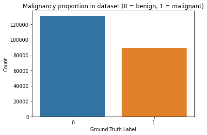

```python
counts = label_df["label"].value_counts()
print(type(counts))
plot = sns.barplot(x = counts.index, y = counts)
plot.set(xlabel = "Ground Truth Label",
        ylabel = "Count",
        title = "Malignancy proportion in dataset (0 = benign, 1 = malignant)")
```

We can see that the data set is more balanced than we might have assumed if these samples had been drawn randomly from the population. But the distribution may make more sense if we assume that only individuals with symptoms or precursors of malignancy are being sampled. Since this is close to a 50-50 split we wont have to further curtail the dataset to give the learning algorithm a better chance of accurately identifying malignancy.

### Create List with all file handles for training data

```python
#Create list of image files, and check to make sure that the

direc = 'histopathologic-cancer-detection\\train\\'
files = os.listdir(direc)
print(f"There are {len(files)} files in the train directory")
assert len(files) == sum(counts.values)

#create a function fp (filepath) that will add the directory on the file names
def fp(direc, file):
    return f"{direc}{file}"
```

### Creating a transformer for our data

The transformer will be responsible from converting our images into the array like structures (tensors) that our Convolutional nueral network will operate on.

```python
# For the first round of architecture we will try a 96x96 transformation (the original size of the picture)
# For future architectures we will consider additional transforms including but not limited to horizontal and vertical
# reflection and rotations of images.

data_transformer = transforms.Compose([transforms.Resize((96, 96)),
                                       transforms.ToTensor(),
                                       transforms.Normalize(mean=(0.5, 0.5, 0.5), std=(0.5, 0.5, 0.5))])
```

```python
#Attempt a first transformation to make sure it worked
image = Image.open(fp(direc, files[99]))
image = data_transformer(image)
print(f"image has shape {image.shape}")
```

### Use of Data Storage Class and Data Loaders

I struggled for a bit wondering how best to store the data and give it to the CNN as we move forward with the project. While looking for solutions I came across two kaggle notebooks that used similar solutions to the problem. They both designed a class to store the data and then implemented a DataLoader. So for transparency's sake I've included a link to both notebooks below, and I have left the earlier attempt unedited above. This will mean there is some overlap in what we're accomplishing.

1. https://www.kaggle.com/code/shtrausslearning/pytorch-cnn-binary-image-classification/notebook#1
2. https://www.kaggle.com/code/oknashar/histopathologic-cancer-detection-using-pytorch

Finally the documentation on Data storage and Loading proved extremely useful: https://pytorch.org/tutorials/beginner/basics/data_tutorial.html

```python
# Data Storage Class
#We need the class to accomplish 3 things, initialize based on set of data it is given, return length of given data, and
#provide a method for getting the items.
#We will use the pytorch Dataset class as a parent class

class data_storage(Dataset):

    def __init__(self, directory, transformation):
        '''
            Initialize the data storage object by retriving file_handles and constructing
            label data frame

            params:
                directory - Full directory path where the files of interest are to be found
                transformation - The transformation we wish to apply to all of the files (at a
                minimum this must include .To_Vector())

            returns:
                None
        '''
        #Create list of files
        file_names = os.listdir(directory)

        #Reduced data set for setting up the CNN
        self.files = [os.path.join(directory, file_name) for file_name in os.listdir(directory)]
#        self.files = [os.path.join(directory, file_name) for file_name in os.listdir(directory)]

        #Get labels from csv file
        if 'test' not in directory:
            label_df = pd.read_csv("histopathologic-cancer-detection\\train_labels.csv", index_col = 'id')
        else:
            label_df = pd.read_csv("histopathologic-cancer-detection\\sample_submission.csv", index_col = 'id')

        #Get the case name without the .tif ending from the filehandles to be used for indexing label_df
        self.case_id = [file_handle[:-4] for file_handle in file_names]

        #Create a list of labels that will match the order of cases in self.files
        self.labels = [label_df.loc[id_value].values[0] for id_value in self.case_id]

        #Store the transformation passed to the storage object, this will make it easier to make
        #adjustments to the feature modifications during hyperparameter tuning

        self.transformation = transformation

    def __getitem__(self, index):

        '''
            Returns transformed image and label at index location

            params:
                index - Numeric index of file to open

            returns:
                Transformed Image, Label
        '''

        #This will return a CNN ready object, meaning it needs to open the image with PIL Image.open() method,
        #transform the image with the given transform, and return image AND label.

        return self.transformation(Image.open(self.files[index])), self.labels[index]

    def __len__(self):

        '''
            Returns the number of files stored in the object

            params:

            returns:
                Number of files in object

        '''

        #gives the number of files in the object
        return len(self.files)
```

```python
# Load data with our new data storage class
data = data_storage("histopathologic-cancer-detection\\train\\", data_transformer)
```

```python
print(len(data))
```

```
220025
```

Here we are going to use the random_split method of pytorch to create our train and validation data sets. The train set will account for approximately 80% of the data, while the validation will account for the other 20%.

```python
# Now that we have the data loaded in our custom version of the Dataset class, we will
# split the data using the random_split method from pytorch

#set seed for reproducibility
torch.manual_seed(111)

train_data, validation_data = random_split(data, [int(0.8 * len(data)), len(data) - int(0.8 * len(data))])
```

```python
print(f"Training data has {len(train_data)} images, validation data has {len(validation_data)}")
print(f"This accounts for a total of {len(train_data) + len(validation_data)} images")
assert len(train_data) + len(validation_data) == len(data)
```

### DataLoaders

After reading the documentation, DataLoaders are a convenient built in way of iterating through data. We will start with a batch size of 64 as given in the documentation for DataLoaders.

```python
train_loader = DataLoader(train_data, batch_size = 64, shuffle = True)
validation_loader = DataLoader(validation_data, batch_size = 64, shuffle = True)
```

## 3. Initial Model Architecture

To calculate the dimensions between layers we can look to 2d convolution documentation for a formula: https://pytorch.org/docs/stable/generated/torch.nn.Conv2d.html

```python
def Conv_Out_Shape(h, w, convolution, pool = 0):
    dilation = convolution.dilation
    stride = convolution.stride
    kernel_size = convolution.kernel_size
    padding = convolution.padding

    hout = math.floor((h + 2 * padding[0] - dilation[0] * (kernel_size[0] - 1) - 1)/stride[0] + 1)
    wout = math.floor((w + 2 * padding[1] - dilation[1] * (kernel_size[1] - 1) - 1)/stride[1] + 1)

    if pool != 0:
        hout = int(hout / pool)
        wout = int(wout / pool)
    return hout, wout
```

```python
class Cancer_Detection_CNN(nn.Module):

    def __init__(self, hyper_parameters):

        #initialize based of of Super class nn.Module
        super(Cancer_Detection_CNN, self).__init__()

        C, H, W = hyper_parameters["shape"]
        filters = hyper_parameters["filters"]
        linear_neurons = hyper_parameters["linear_neurons"]
        self.dropout = hyper_parameters["dropout"]

        #We are going to define 2 convolution layers here, calculating dimensions between
        self.first_convolution = nn.Conv2d(C, filters, kernel_size = 3)
        height, width = Conv_Out_Shape(H, W, self.first_convolution, pool = 2)
        self.second_convolution = nn.Conv2d(filters, filters, kernel_size = 3)
        height, width = Conv_Out_Shape(height, width, self.second_convolution, pool = 2)
        self.third_convolution = nn.Conv2d(filters, filters, kernel_size = 3)
        height, width = Conv_Out_Shape(height, width, self.second_convolution, pool = 2)
        self.fourth_convolution = nn.Conv2d(filters, filters, kernel_size = 3)
        height, width = Conv_Out_Shape(height, width, self.second_convolution, pool = 2)

        #Linear layers
        self.flat_dim = height * width * filters
        self.first_linear = nn.Linear(self.flat_dim, linear_neurons)
        self.second_linear = nn.Linear(linear_neurons, 2)

    #Our forward propogation will be Conv1 -> Conv2 -> Pool -> Linear1 -> Linear2 -> Output
    def forward(self, intake):

        #Each convolution layer will get a relu activation function
        intake = F.relu(self.first_convolution(intake))

        #Pool result of convolution
        intake = F.max_pool2d(intake, 2, 2)

        #Second convolution
        intake = F.relu(self.second_convolution(intake))

        #Pool result of Convolution
        intake = F.max_pool2d(intake, 2, 2)

        #Third convolution
        intake = F.relu(self.third_convolution(intake))

        #Pool result of Convolution
        intake = F.max_pool2d(intake, 2, 2)

        #Fourt convolution
        intake = F.relu(self.fourth_convolution(intake))

        #Pool result of Convolution
        intake = F.max_pool2d(intake, 2, 2)

        #Flatten Pool
        intake = intake.view(-1, self.flat_dim)

        #Linear layer 1 will get Relu while 2nd layer will get log_softmax
        intake = F.relu(self.first_linear(intake))

        #Apply Dropout after first dense layer
        intake = F.dropout(intake, self.dropout)

        #Final linear layer
        intake = self.second_linear(intake)

        #Output activation function
        return F.log_softmax(intake, dim = 1)
```

```python
first_pass_parameters = {
    "shape" : (3, 96, 96),
    "filters" : 4,
    "linear_neurons" : 250,
    "dropout" : 0.2,
}
```

```python
First_Model = Cancer_Detection_CNN(first_pass_parameters)
gpu = torch.cuda.is_available()
hardware = ''
if gpu:
    hardware = 'cuda'
else:
    hardware = 'cpu'
print(hardware)
First_Model.to(hardware)
print(First_Model)
```

### Loss function and Optimizer.

For loss functions I selected from the documentation: https://pytorch.org/docs/stable/nn.functional.html#loss-functions For this project I chose CrossEntropyLoss as the loss function for its ability to act as solid first choice in almost all classification settings. One of the avenues to pursue further would be identifying a loss function that may help our model achieve more accurate results. Another option that was considered but not used due to changes that would need to be effected in the Data Storage mechanism was Binary Cross Entropy Loss. In a future rendition of this project I would like to see if switching to Binary Cross Entropy produces more favorable results

For the optimizer I also selected from the documentation: https://pytorch.org/docs/stable/optim.html I selected the Adam optimizer because it takes the strengths of several other optimization methods and combines them into a single methodology. Since I lack domain knowledge and extensive experience with this dataset I don't believe I could select an optimizer better suited for this problem than Adam.

```python
#For binary classification we will start with cross entropy loss
Loss_fx = nn.CrossEntropyLoss()

#And for optimization we will use Adam, from all of the publically available notebooks for
#this project it appears that Adam is prefered.
optimizer = Adam(First_Model.parameters(), lr = 3e-4)
```

### Function for inputing hyperparameters and getting validation results

Hyperparameters we will take into account:

```
-epochs
-loss function
-optimiser
-learning rate
-number of filters per layer in the architecture
```

The following function will serve as our model training, validating, and reporting function. It will take the model architecture, the hyperparameters, and train and validate a model. The output will be histories for the training and validation loss as well as histories for the training and validation accuracy. This way we will be able to compare the performance of our models over different epochs.

```python
def run_cnn(model, criterion, optimizer, train_data_loader, validate_data_loader, device, epochs):
    training_loss_history = []
    training_corrects_history = []
    val_loss_history = []
    val_corrects_history = []
    best_acc = 0.0
    min_loss = np.Inf

    for i in range(epochs):
        print(f"Epoch = {i + 1}/{epochs}")
        running_loss = 0.0
        running_corrects = 0.0
        val_running_loss = 0.0
        val_running_corrects = 0.0

        print(f"Forward Pass")
        running_total = 1
        for inputs, labels in train_data_loader:
            if running_total %100 == 0:
                print(f"Element {running_total}/{len(train_data_loader.dataset)}")
            running_total += 1
            inputs = inputs.to(device)
            labels = labels.to(device)

            outputs = model(inputs)

            loss = criterion(outputs, labels)

            optimizer.zero_grad()

            loss.backward()

            optimizer.step()

            _, preds = torch.max(outputs, 1)

            running_loss += loss.item()

            running_corrects += torch.sum(preds == labels.data)

        else:
            with torch.no_grad():
                for val_inputs, val_labels in validate_data_loader:
                    val_inputs = val_inputs.to(device)
                    val_labels = val_labels.to(device)

                    val_outputs = model(val_inputs)

                    val_loss = criterion(val_outputs, val_labels)

                    _, val_preds = torch.max(val_outputs, 1)

                    val_running_loss += val_loss.item()

                    val_running_corrects += torch.sum(val_preds == val_labels.data)

        epoch_loss = running_loss/len(train_data_loader.dataset)
        training_loss_history.append(epoch_loss)

        epoch_acc = running_corrects.float()/len(train_data_loader.dataset)
        training_corrects_history.append(epoch_acc)

        val_epoch_loss = val_running_loss/len(validate_data_loader.dataset)
        val_loss_history.append(val_epoch_loss)

        val_epoch_acc = val_running_corrects.float()/len(validate_data_loader.dataset)
        val_corrects_history.append(val_epoch_acc)

        if best_acc < val_epoch_acc:
            best_acc = val_epoch_acc

        if min_loss >= val_epoch_loss:
            torch.save(model.state_dict(), 'best_model.pt')
            min_loss = val_epoch_loss

        print(f'epoch :{i+1}')
        print(f'training loss: {round(epoch_loss, 4)}, Training accuracy {round(epoch_acc.item(), 4)}')
        print(f'validation loss: {round(val_epoch_loss,4)}, validation accuracy {round(val_epoch_acc.item(),4)} ')

    return model, training_loss_history, training_corrects_history, val_loss_history, val_corrects_history
```

This is our first instantiation of our architecture as well as implementation of our train, validate, report function.

```python
data = data_storage("histopathologic-cancer-detection\\train\\", data_transformer)
# Now that we have the data loaded in our custom version of the Dataset class, we will
# split the data using the random_split method from pytorch

#set seed for reproducibility
torch.manual_seed(111)

train_data, validation_data = random_split(data, [int(0.8 * len(data)), len(data) - int(0.8 * len(data))])

train_loader = DataLoader(train_data, batch_size = 64, shuffle = True)
validation_loader = DataLoader(validation_data, batch_size = 64, shuffle = True)
device = 'cuda'
first_pass_parameters = {
    "shape" : (3, 96, 96),
    "filters" : 4,
    "linear_neurons" : 250,
    "dropout" : 0.2,
}
model = Cancer_Detection_CNN(first_pass_parameters)
model.to(device)
#For binary classification we will start with cross entropy loss
Loss_fx = nn.CrossEntropyLoss()

#And for optimization we will use Adam, from all of the publically available notebooks for
#this project it appears that Adam is prefered.
optimizer = Adam(model.parameters(), lr = .001)

m, tlh, tch, vlh, bch = run_cnn(model, Loss_fx, optimizer, train_loader, validation_loader, device, 30)
```

```
Epoch = 1/30
Forward Pass
Element 100/176020
Element 200/176020
Element 300/176020
Element 400/176020
Element 500/176020
Element 600/176020
Element 700/176020
Element 800/176020
Element 900/176020
Element 1000/176020
Element 1100/176020
Element 1200/176020
Element 1300/176020
Element 1400/176020
Element 1500/176020
Element 1600/176020
Element 1700/176020
Element 1800/176020
Element 1900/176020
Element 2000/176020
Element 2100/176020
Element 2200/176020
Element 2300/176020
Element 2400/176020
Element 2500/176020
Element 2600/176020
Element 2700/176020
epoch :1
training loss: 0.0074, Training accuracy 0.7814
validation loss: 0.0074, validation accuracy 0.777
Epoch = 2/30
Forward Pass
Element 100/176020
Element 200/176020
Element 300/176020
Element 400/176020
Element 500/176020
Element 600/176020
```

[output cut: 905 more lines]

```
Element 1600/176020
Element 1700/176020
Element 1800/176020
Element 1900/176020
Element 2000/176020
Element 2100/176020
Element 2200/176020
Element 2300/176020
Element 2400/176020
Element 2500/176020
Element 2600/176020
Element 2700/176020
epoch :30
training loss: 0.0048, Training accuracy 0.8687
validation loss: 0.005, validation accuracy 0.8637
```

## 4. Analysis of Results

Over 30 epochs our model was able to achieve a minimum validation loss of 0.0049 in the 21st epoch. This equated to a validation accuracy of approximately 86.27%.

```python
Results = pd.DataFrame()
Results["Training_Loss"] = tlh
Results["Validation_Loss"] = vlh

Accuracy_Results = pd.DataFrame()
Accuracy_Results["Training_Accuracy"] = [x.item() for x in tch]
Accuracy_Results["Validation_Accuracy"] = [x.item() for x in bch]
```

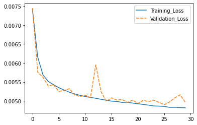

```python
sns.lineplot(data=Results)
```

We can see that the training loss continues to decrease as the epochs continue although at a much slower pace toward the 30th epoch. The validation loss however seems to plateau around epoch 20. Increasing the number of epochs may improve model performance slighlty, but the validation loss would suggest otherwise.

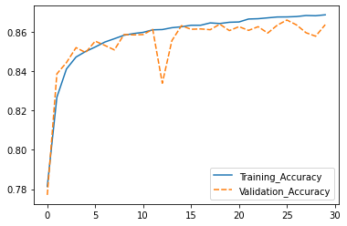

```python
sns.lineplot(data=Accuracy_Results)
```

## 5. Alternate Architecture and Hyperparameter Tuning

Additionaly the transformer will have several new elements added to it for a more robust consideration of the data and how it may appear in non training scenarios.

```python
data_transformer = transforms.Compose([transforms.RandomHorizontalFlip(p=0.25),
                                       transforms.RandomVerticalFlip(p=0.25),
                                       transforms.RandomRotation(45),
                                       transforms.Resize((96, 96)),
                                       transforms.ToTensor(),
                                       transforms.Normalize(mean=(0.5, 0.5, 0.5), std=(0.5, 0.5, 0.5))])
```

```python
#New Architecture 1
# 6x (Convolution -> Pool) -> 1x Dense Layer -> 1x Output Layer
# Added a padding of 1 onto each convolutional layer
# Increased Dense layer to 750 neurons
# Increased the number of filters to 8

class Cancer_Detection_CNN(nn.Module):

    def __init__(self, hyper_parameters):

        #initialize based of of Super class nn.Module
        super(Cancer_Detection_CNN, self).__init__()

        C, H, W = hyper_parameters["shape"]
        filters = hyper_parameters["filters"]
        linear_neurons = hyper_parameters["linear_neurons"]
        self.dropout = hyper_parameters["dropout"]

        #We are going to define 2 convolution layers here, calculating dimensions between
        self.first_convolution = nn.Conv2d(C, filters, kernel_size = 3, padding = 1)
        height, width = Conv_Out_Shape(H, W, self.first_convolution, pool = 2)
        self.second_convolution = nn.Conv2d(filters, filters, kernel_size = 3, padding = 1)
        height, width = Conv_Out_Shape(height, width, self.second_convolution, pool = 2)
        self.third_convolution = nn.Conv2d(filters, filters, kernel_size = 3, padding = 1)
        height, width = Conv_Out_Shape(height, width, self.second_convolution, pool = 2)
        self.fourth_convolution = nn.Conv2d(filters, filters, kernel_size = 3, padding = 1)
        height, width = Conv_Out_Shape(height, width, self.second_convolution, pool = 2)
        self.fifth_convolution = nn.Conv2d(filters, filters, kernel_size = 3, padding = 1)
        height, width = Conv_Out_Shape(height, width, self.second_convolution, pool = 2)
        self.sixth_convolution = nn.Conv2d(filters, filters, kernel_size = 3, padding = 1)
        height, width = Conv_Out_Shape(height, width, self.second_convolution, pool = 2)

        #Linear layers
        self.flat_dim = height * width * filters
        self.first_linear = nn.Linear(self.flat_dim, linear_neurons)
        self.second_linear = nn.Linear(linear_neurons, 2)

    #Our forward propogation will be Conv1 -> Conv2 -> Pool -> Linear1 -> Linear2 -> Output
    def forward(self, intake):

        #Each convolution layer will get a relu activation function
        intake = F.relu(self.first_convolution(intake))

        #Pool result of convolution
        intake = F.max_pool2d(intake, 2, 2)

        #Second convolution
        intake = F.relu(self.second_convolution(intake))

        #Pool result of Convolution
        intake = F.max_pool2d(intake, 2, 2)

        #Third convolution
        intake = F.relu(self.third_convolution(intake))

        #Pool result of Convolution
        intake = F.max_pool2d(intake, 2, 2)

        #Fourth convolution
        intake = F.relu(self.fourth_convolution(intake))

        #Pool result of Convolution
        intake = F.max_pool2d(intake, 2, 2)

        #Fifth convolution
        intake = F.relu(self.fifth_convolution(intake))

        #Pool result of Convolution
        intake = F.max_pool2d(intake, 2, 2)

        #Sixth convolution
        intake = F.relu(self.sixth_convolution(intake))

        #Pool result of Convolution
        intake = F.max_pool2d(intake, 2, 2)

        #Flatten Pool
        intake = intake.view(-1, self.flat_dim)

        #Linear layer 1 will get Relu while 2nd layer will get log_softmax
        intake = F.relu(self.first_linear(intake))

        #Apply Dropout after first dense layer
        intake = F.dropout(intake, self.dropout)

        #Final linear layer
        intake = self.second_linear(intake)

        #Output activation function
        return F.log_softmax(intake, dim = 1)

data = data_storage("histopathologic-cancer-detection\\train\\", data_transformer)
# Now that we have the data loaded in our custom version of the Dataset class, we will
# split the data using the random_split method from pytorch

#set seed for reproducibility
torch.manual_seed(111)

train_data, validation_data = random_split(data, [int(0.8 * len(data)), len(data) - int(0.8 * len(data))])

train_loader = DataLoader(train_data, batch_size = 64, shuffle = True)
validation_loader = DataLoader(validation_data, batch_size = 64, shuffle = True)
device = 'cuda'
first_pass_parameters = {
    "shape" : (3, 96, 96),
    "filters" : 8,
    "linear_neurons" : 750,
    "dropout" : 0.2,
}
model1 = Cancer_Detection_CNN(first_pass_parameters)
model1.to(device)
#For binary classification we will start with cross entropy loss
Loss_fx = nn.CrossEntropyLoss()

#And for optimization we will use Adam, from all of the publically available notebooks for
#this project it appears that Adam is prefered.
optimizer = Adam(model1.parameters(), lr = .001)

alt1_m, alt1_tlh, alt1_tch, alt1_vlh, alt1_bch = run_cnn(model1, Loss_fx, optimizer, train_loader, validation_loader, device, 10)
```

[output not shown]

[output cut: 117 more lines]

[output not shown]

[output not shown]

```python
# New Architecture 2
# 1x Convolution(3x3) -> Pool -> 1x Convolution(5x5) -> Pool -> 1x Convolution(3x3) -> Pool ->
# 1x Convoution(1x1) -> Pool -> 1x Dense Layer -> 1x Output Layer
# Increased dense layer to 750 Neurons
# Increased Filters to 8

class Cancer_Detection_CNN(nn.Module):

    def __init__(self, hyper_parameters):

        #initialize based of of Super class nn.Module
        super(Cancer_Detection_CNN, self).__init__()

        C, H, W = hyper_parameters["shape"]
        filters = hyper_parameters["filters"]
        linear_neurons = hyper_parameters["linear_neurons"]
        self.dropout = hyper_parameters["dropout"]

        #We are going to define 2 convolution layers here, calculating dimensions between
        self.first_convolution = nn.Conv2d(C, filters, kernel_size = 3)
        height, width = Conv_Out_Shape(H, W, self.first_convolution, pool = 2)
        self.second_convolution = nn.Conv2d(filters, filters, kernel_size = 3)
        height, width = Conv_Out_Shape(height, width, self.second_convolution, pool = 2)
        self.third_convolution = nn.Conv2d(filters, filters, kernel_size = 3)
        height, width = Conv_Out_Shape(height, width, self.second_convolution, pool = 2)
        self.fourth_convolution = nn.Conv2d(filters, filters, kernel_size = 3)
        height, width = Conv_Out_Shape(height, width, self.second_convolution, pool = 2)

        #Linear layers
        self.flat_dim = height * width * filters
        self.first_linear = nn.Linear(self.flat_dim, linear_neurons)
        self.second_linear = nn.Linear(linear_neurons, 2)

    #Our forward propogation will be Conv1 -> Conv2 -> Pool -> Linear1 -> Linear2 -> Output
    def forward(self, intake):

        #Each convolution layer will get a relu activation function
        intake = F.relu(self.first_convolution(intake))

        #Pool result of convolution
        intake = F.max_pool2d(intake, 2, 2)

        #Second convolution
        intake = F.relu(self.second_convolution(intake))

        #Pool result of Convolution
        intake = F.max_pool2d(intake, 2, 2)

        #Third convolution
        intake = F.relu(self.third_convolution(intake))

        #Pool result of Convolution
        intake = F.max_pool2d(intake, 2, 2)

        #Fourt convolution
        intake = F.relu(self.fourth_convolution(intake))

        #Pool result of Convolution
        intake = F.max_pool2d(intake, 2, 2)

        #Flatten Pool
        intake = intake.view(-1, self.flat_dim)

        #Linear layer 1 will get Relu while 2nd layer will get log_softmax
        intake = F.relu(self.first_linear(intake))

        #Apply Dropout after first dense layer
        intake = F.dropout(intake, self.dropout)

        #Final linear layer
        intake = self.second_linear(intake)

        #Output activation function
        return F.log_softmax(intake, dim = 1)

data = data_storage("histopathologic-cancer-detection\\train\\", data_transformer)
# Now that we have the data loaded in our custom version of the Dataset class, we will
# split the data using the random_split method from pytorch

#set seed for reproducibility
torch.manual_seed(111)

train_data, validation_data = random_split(data, [int(0.8 * len(data)), len(data) - int(0.8 * len(data))])

train_loader = DataLoader(train_data, batch_size = 64, shuffle = True)
validation_loader = DataLoader(validation_data, batch_size = 64, shuffle = True)
device = 'cuda'
first_pass_parameters = {
    "shape" : (3, 96, 96),
    "filters" : 8,
    "linear_neurons" : 750,
    "dropout" : 0.2,
}
model = Cancer_Detection_CNN(first_pass_parameters)
model.to(device)
#For binary classification we will start with cross entropy loss
Loss_fx = nn.CrossEntropyLoss()

#And for optimization we will use Adam, from all of the publically available notebooks for
#this project it appears that Adam is prefered.
optimizer = Adam(model.parameters(), lr = .001)

alt2_m, alt2_tlh, alt2_tch, alt2_vlh, alt2_bch = run_cnn(model, Loss_fx, optimizer, train_loader, validation_loader, device, 10)
```

```
Epoch = 1/10
Forward Pass
Element 100/176020
Element 200/176020
Element 300/176020
Element 400/176020
Element 500/176020
Element 600/176020
Element 700/176020
Element 800/176020
Element 900/176020
Element 1000/176020
Element 1100/176020
Element 1200/176020
Element 1300/176020
Element 1400/176020
Element 1500/176020
Element 1600/176020
Element 1700/176020
Element 1800/176020
Element 1900/176020
Element 2000/176020
Element 2100/176020
Element 2200/176020
Element 2300/176020
Element 2400/176020
Element 2500/176020
Element 2600/176020
Element 2700/176020
epoch :1
training loss: 0.0068, Training accuracy 0.8048
validation loss: 0.0059, validation accuracy 0.8379
Epoch = 2/10
Forward Pass
Element 100/176020
Element 200/176020
Element 300/176020
Element 400/176020
Element 500/176020
Element 600/176020
```

[output cut: 265 more lines]

```
Element 1600/176020
Element 1700/176020
Element 1800/176020
Element 1900/176020
Element 2000/176020
Element 2100/176020
Element 2200/176020
Element 2300/176020
Element 2400/176020
Element 2500/176020
Element 2600/176020
Element 2700/176020
epoch :10
training loss: 0.0047, Training accuracy 0.8759
validation loss: 0.0047, validation accuracy 0.8738
```

```python
#New Architecture 3
#Same as the first architecture, except with average pool replacing maxpool
# 6x (Convolution -> Pool) -> 1x Dense Layer -> 1x Output Layer
# Added a padding of 1 onto each convolutional layer
# Increased Dense layer to 750 neurons
# Increased the number of filters to 8

class Cancer_Detection_CNN(nn.Module):

    def __init__(self, hyper_parameters):

        #initialize based of of Super class nn.Module
        super(Cancer_Detection_CNN, self).__init__()

        C, H, W = hyper_parameters["shape"]
        filters = hyper_parameters["filters"]
        linear_neurons = hyper_parameters["linear_neurons"]
        self.dropout = hyper_parameters["dropout"]

        #We are going to define 2 convolution layers here, calculating dimensions between
        self.first_convolution = nn.Conv2d(C, filters, kernel_size = 3, padding = 1)
        height, width = Conv_Out_Shape(H, W, self.first_convolution, pool = 2)
        self.second_convolution = nn.Conv2d(filters, filters, kernel_size = 3, padding = 1)
        height, width = Conv_Out_Shape(height, width, self.second_convolution, pool = 2)
        self.third_convolution = nn.Conv2d(filters, filters, kernel_size = 3)
        height, width = Conv_Out_Shape(height, width, self.second_convolution, pool = 2)
        self.fourth_convolution = nn.Conv2d(filters, filters, kernel_size = 3, padding = 1)
        height, width = Conv_Out_Shape(height, width, self.second_convolution, pool = 2)
        self.fifth_convolution = nn.Conv2d(filters, filters, kernel_size = 3, padding = 1)
        height, width = Conv_Out_Shape(height, width, self.second_convolution, pool = 2)
        self.sixth_convolution = nn.Conv2d(filters, filters, kernel_size = 3, padding = 1)
        height, width = Conv_Out_Shape(height, width, self.second_convolution, pool = 2)

        #Linear layers
        self.flat_dim = height * width * filters
        self.first_linear = nn.Linear(self.flat_dim, linear_neurons)
        self.second_linear = nn.Linear(linear_neurons, 2)

    #Our forward propogation will be Conv1 -> Conv2 -> Pool -> Linear1 -> Linear2 -> Output
    def forward(self, intake):

        #Each convolution layer will get a relu activation function
        intake = F.relu(self.first_convolution(intake))

        #Pool result of convolution
        intake = F.avg_pool2d(intake, 2, 2)

        #Second convolution
        intake = F.relu(self.second_convolution(intake))

        #Pool result of Convolution
        intake = F.avg_pool2d(intake, 2, 2)

        #Third convolution
        intake = F.relu(self.third_convolution(intake))

        #Pool result of Convolution
        intake = F.avg_pool2d(intake, 2, 2)

        #Fourth convolution
        intake = F.relu(self.fourth_convolution(intake))

        #Pool result of Convolution
        intake = F.avg_pool2d(intake, 2, 2)

        #Fifth convolution
        intake = F.relu(self.fifth_convolution(intake))

        #Pool result of Convolution
        intake = F.avg_pool2d(intake, 2, 2)

        #Sixth convolution
        intake = F.relu(self.sixth_convolution(intake))

        #Pool result of Convolution
        intake = F.avg_pool2d(intake, 2, 2)

        #Flatten Pool
        intake = intake.view(-1, self.flat_dim)

        #Linear layer 1 will get Relu while 2nd layer will get log_softmax
        intake = F.relu(self.first_linear(intake))

        #Apply Dropout after first dense layer
        intake = F.dropout(intake, self.dropout)

        #Final linear layer
        intake = self.second_linear(intake)

        #Output activation function
        return F.log_softmax(intake, dim = 1)

data = data_storage("histopathologic-cancer-detection\\train\\", data_transformer)
# Now that we have the data loaded in our custom version of the Dataset class, we will
# split the data using the random_split method from pytorch

#set seed for reproducibility
torch.manual_seed(111)

train_data, validation_data = random_split(data, [int(0.8 * len(data)), len(data) - int(0.8 * len(data))])

train_loader = DataLoader(train_data, batch_size = 64, shuffle = True)
validation_loader = DataLoader(validation_data, batch_size = 64, shuffle = True)
device = 'cuda'
first_pass_parameters = {
    "shape" : (3, 96, 96),
    "filters" : 8,
    "linear_neurons" : 750,
    "dropout" : 0.2,
}
model = Cancer_Detection_CNN(first_pass_parameters)
model.to(device)
#For binary classification we will start with cross entropy loss
Loss_fx = nn.CrossEntropyLoss()

#And for optimization we will use Adam, from all of the publically available notebooks for
#this project it appears that Adam is prefered.
optimizer = Adam(model.parameters(), lr = .001)

alt3_m, alt3_tlh, alt3_tch, alt3_vlh, alt3_bch = run_cnn(model, Loss_fx, optimizer, train_loader, validation_loader, device, 10)
```

```
Epoch = 1/10
Forward Pass
Element 100/176020
Element 200/176020
Element 300/176020
Element 400/176020
Element 500/176020
Element 600/176020
Element 700/176020
Element 800/176020
Element 900/176020
Element 1000/176020
Element 1100/176020
Element 1200/176020
Element 1300/176020
Element 1400/176020
Element 1500/176020
Element 1600/176020
Element 1700/176020
Element 1800/176020
Element 1900/176020
Element 2000/176020
Element 2100/176020
Element 2200/176020
Element 2300/176020
Element 2400/176020
Element 2500/176020
Element 2600/176020
Element 2700/176020
epoch :1
training loss: 0.007, Training accuracy 0.7983
validation loss: 0.0068, validation accuracy 0.7979
Epoch = 2/10
Forward Pass
Element 100/176020
Element 200/176020
Element 300/176020
Element 400/176020
Element 500/176020
Element 600/176020
```

[output cut: 265 more lines]

```
Element 1600/176020
Element 1700/176020
Element 1800/176020
Element 1900/176020
Element 2000/176020
Element 2100/176020
Element 2200/176020
Element 2300/176020
Element 2400/176020
Element 2500/176020
Element 2600/176020
Element 2700/176020
epoch :10
training loss: 0.0043, Training accuracy 0.8875
validation loss: 0.0042, validation accuracy 0.888
```

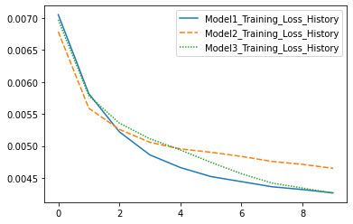

```python
import seaborn as sns
training_loss = pd.DataFrame()
training_loss["Model1_Training_Loss_History"] = alt1_tlh
training_loss["Model2_Training_Loss_History"] = alt2_tlh
training_loss["Model3_Training_Loss_History"] = alt3_tlh
sns.lineplot(data = training_loss)
```

The training loss for our models maintains a slight downwards trend towards the 10th epoch, indicating that 10 epochs may not have been enough time to achieve our optimal model performance from a training perspective. However when compared to the validation loss history it seems that we have indeed achieved our optimal performance by the 9th epoch.

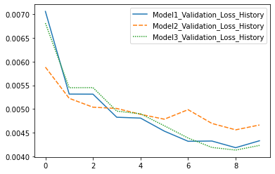

```python
validation_loss = pd.DataFrame()
validation_loss["Model1_Validation_Loss_History"] = alt1_vlh
validation_loss["Model2_Validation_Loss_History"] = alt2_vlh
validation_loss["Model3_Validation_Loss_History"] = alt3_vlh
sns.lineplot(data = validation_loss)
```

```python
alt1_tch
```

```
[tensor(0.7938, device='cuda:0'),
 tensor(0.8384, device='cuda:0'),
 tensor(0.8580, device='cuda:0'),
 tensor(0.8684, device='cuda:0'),
 tensor(0.8747, device='cuda:0'),
 tensor(0.8795, device='cuda:0'),
 tensor(0.8823, device='cuda:0'),
 tensor(0.8851, device='cuda:0'),
 tensor(0.8856, device='cuda:0'),
 tensor(0.8874, device='cuda:0')]
```

[figure not shown]

```python
training_accuracy = pd.DataFrame()
training_accuracy["Model1_Training_Accuracy_History"] = [x.item() for x in alt1_tch]
training_accuracy["Model2_Training_Accuracy_History"] = [x.item() for x in alt2_tch]
training_accuracy["Model3_Training_Accuracy_History"] = [x.item() for x in alt3_tch]
sns.lineplot(data = training_accuracy)
```

[figure not shown]

```python
validation_accuracy = pd.DataFrame()
validation_accuracy["Model1_Validation_Accuracy_History"] = [x.item() for x in alt1_bch]
validation_accuracy["Model2_Validation_Accuracy_History"] = [x.item() for x in alt2_bch]
validation_accuracy["Model3_Validation_Accuracy_History"] = [x.item() for x in alt3_bch]
sns.lineplot(data = validation_accuracy)
```

## 6. Conclusion

While all of the models we trained for this problem seemed to come to a stable convergent condition within their alloted number of epochs some certainly outperformed others. The additional complexity introduced in the 1st and 3rd models seems to have made a significant impact on the performance and lend themselves to further research with even more complex models. Additionally adding more layers in the first dense layers output had a positive impact on all 3 alternate architectures.

Since the data presents a complex set of patterns with multiple types of variation it makes sense that the more complicated models produced better results.

Future steps with this project should focus on identifying domain specific knowledge that could be incorporated into the problem in the form of transforms or model architecture will also exploring the use of alternative loss functions (Binary Cross Entropy Loss seems like a very good contender).

```python
# Bonus generate outputs for Kaggle competition with Alternat Architecture number 1.
model_for_submission = alt1_m
```

```python
#Load in data for submission
sub_dat = data_storage('histopathologic-cancer-detection\\test\\', data_transformer)
```

```python
sub_data = DataLoader(sub_dat, batch_size = 64, shuffle = False)
```

```python
model_for_submission.load_state_dict(torch.load('best_model.pt'))
model_for_submission.eval()
```

[output not shown]

```python
predictions = []

#Iterate through all images in submission data
for (image, label) in sub_data:

    #send images and labels to gpu
    image = image.to(device)
    label = label.to(device)

    #have the model predict for the batch of images
    out = model_for_submission(image)
    _, preds = torch.max(out, 1)
    predicted = preds

    #Append each prediction
    for predict in predicted:
        predictions.append(predict.item())
```

```python
final_submission = pd.read_csv('histopathologic-cancer-detection\\sample_submission.csv')
for i, element in enumerate(sub_dat.case_id):
    print(i)
    element_index = int(final_submission.index[final_submission['id'] == element][0])
    final_submission.iat[element_index, 1] = int(predictions[i])
```

[output not shown]

[output cut: 57403 more lines]

[output not shown]

```python
final_submission.to_csv('submit.csv', index=False)
```